# 2g_bb_model_comparison

2022-10-14

This data frame has all of the Bristol Bay covariates and final responses from both analyses (Cline et al 2020 data archived on zenodo) and this analysis. The data frame shows where there were some missing data in the UW database compared to what was done in 2020. ~180 site years in 2020 and missing 24 summers of data when I requested the raw data from the UW database so I could get daily min, mean, and max.

```r
bb_dat <- readRDS("output/combined_bb_data.rds")

bb_dat %>%
  count(Stream,uw, Site) %>%
  arrange(Stream)
```

```
## # A tibble: 57 x 4
##    Stream uw                    Site                         n
##    <chr>  <chr>                 <chr>                    <int>
##  1 Allah  Nerka Allah Creek     UW_Nerka Allah Creek         5
##  2 Bear   Aleknagik Bear Creek  UW_Aleknagik Bear Creek      6
##  3 Beaver Nerka Beaver Creek    UW_Nerka Beaver Creek        2
##  4 Berm   Nerka Berm Creek      UW_Nerka Berm Creek          5
##  5 Berm   Nerka Berm Creek      <NA>                         1
##  6 Bug    Nerka Bug Creek       UW_Nerka Bug Creek           1
##  7 C      Little Togiak C Creek UW_Little Togiak C Creek     5
##  8 Cabin  Nerka Cabin Creek     UW_Nerka Cabin Creek         4
##  9 Cabin  Nerka Cabin Creek     <NA>                         1
## 10 Chamee Nerka Chamee Creek    UW_Nerka Chamee Creek        1
## # ... with 47 more rows
## # i Use `print(n = ...)` to see more rows
```

```r
# bb_dat %>% filter(is.na(wtd_slope_MIN)) %>% nrow()
```

See below for different models I tested for the snow residuals: one with watershed slope only, watershed slope squared, and watershed slope + watershed aspect. All models had a random intercept for year. Simple model with just watershed slope had the lowest AIC (delta ~ 5).

The main difference I see in the paper formula and the calculation for raw residuals is that the year intercept term is outside the function for subtracting fitted from observed values.

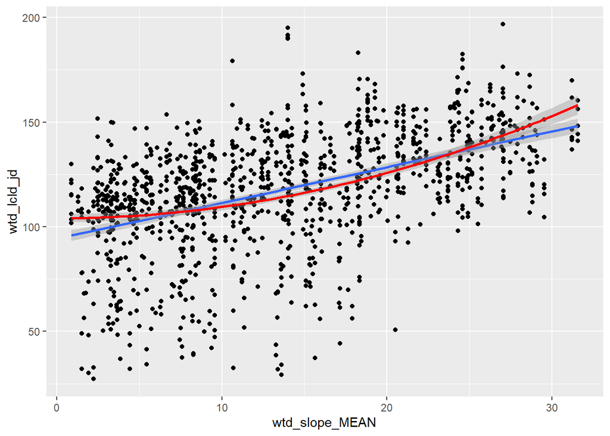

```r
dat <- readRDS("data_preparation/final_data/model_data2022-05-09.rds")


dat %>%
  ggplot(aes(x = wtd_slope_MEAN, y = wtd_lcld_jd)) +
  geom_point() +
  geom_smooth(method = "lm") +
  geom_smooth(color = "red", method = "lm",  formula = y ~ I(x^2))
```

```r
ess_lme1 <- lme(wtd_lcld_jd ~ wtd_slope_MEAN, dat = dat, random = ~1|Year)
ess_lme2 <- lme(wtd_lcld_jd ~ I(wtd_slope_MEAN^2), dat = dat, random = ~1|Year)
ess_lme3 <- lme(wtd_lcld_jd ~ wtd_slope_MEAN + wtd_north_per, dat = dat, random = ~1|Year)

AIC(ess_lme1, ess_lme2, ess_lme3)
```

```
##          df      AIC
## ess_lme1  4 10805.12
## ess_lme2  4 10824.13
## ess_lme3  5 10810.43
```

```r
ess_lme_resid <- residuals(ess_lme1, level = 1)
attributes(ess_lme_resid) <- NULL
str(ess_lme_resid)
```

```
##  num [1:1224] -17.24 -11.84 -3.59 -7.82 -7.98 ...
```

```r
summary(ess_lme_resid)
```

```
##    Min. 1st Qu.  Median    Mean 3rd Qu.    Max.
## -77.902  -9.882   1.575   0.000  11.363  92.699
```

```r
ess_lme_resid2 <- residuals(ess_lme2, level = 1)
attributes(ess_lme_resid) <- NULL
str(ess_lme_resid)
```

```
##  num [1:1224] -17.24 -11.84 -3.59 -7.82 -7.98 ...
```

```r
ess_lme1_ints <- ess_lme1$coefficients$random$Year %>% as_tibble(rownames = "Year") %>%
  rename(intercept = `(Intercept)`) %>%
  mutate(Year = as.numeric(Year))

ess_lme1_ints
```

```
## # A tibble: 9 x 2
##    Year intercept
##   <dbl>     <dbl>
## 1  2011      9.31
## 2  2012     21.6
## 3  2013     23.0
## 4  2014    -10.6
## 5  2015    -24.1
## 6  2016    -18.1
## 7  2017     -1.47
## 8  2018      3.14
## 9  2019     -2.81
```

```r
summary(ess_lme1)
```

```
## Linear mixed-effects model fit by REML
##   Data: dat
##        AIC      BIC   logLik
##   10805.12 10825.55 -5398.56
##
## Random effects:
##  Formula: ~1 | Year
##         (Intercept) Residual
## StdDev:    16.37121 19.61943
##
## Fixed effects:  wtd_lcld_jd ~ wtd_slope_MEAN
##                   Value Std.Error   DF  t-value p-value
## (Intercept)    95.67648  5.570645 1214 17.17512       0
## wtd_slope_MEAN  1.78344  0.070956 1214 25.13464       0
##  Correlation:
##                (Intr)
## wtd_slope_MEAN -0.172
##
## Standardized Within-Group Residuals:
##         Min          Q1         Med          Q3         Max
## -3.97067160 -0.50366785  0.08027434  0.57918163  4.72487943
##
## Number of Observations: 1224
## Number of Groups: 9
```

```r
dat %>% mutate(snow_diff = wtd_lcld_jd - 1.78344* wtd_slope_MEAN) %>%
  select(snow_diff) %>% summary()
```

```
##    snow_diff
##  Min.   :  5.065
##  1st Qu.: 80.159
##  Median : 97.104
##  Mean   : 93.264
##  3rd Qu.:109.395
##  Max.   :170.233
```

```r
#not run: but see equation below for calculating snow_tc based on formula in paper
# dat <- dat %>%
#   left_join(ess_lme1_ints) %>%
#   mutate(snow_ind = ess_lme_resid,
#          snow_ind_sq = ess_lme_resid2,
#          snow_tc = intercept + (wtd_lcld_jd - 1.783443 * wtd_slope_MEAN))
```

These plots show some comparisons between the data on zenodo and for this analysis. All variables on x axis are from zenodo and y are from this analysis.

- watershed slopes are very close, r = 0.98. I would expect some differences due to different DEMs and different watershed polygons.
- SnowResiduals from zenodo have a pretty good fit to the snow index I calculated following the formula in the paper, although the ranges are different, r = 0.92.
- Snow residuals from zenodo do not match the raw residuals (using the innermost level of groupings, so adding the year intercept term) for either models with slope (linear or squared).
- the thermal sensitivities using only air temperatures in the DFA model match pretty good, r = 0.8. The correlation decreases a bit when we compare to the air + daylength model, which is to be expected.

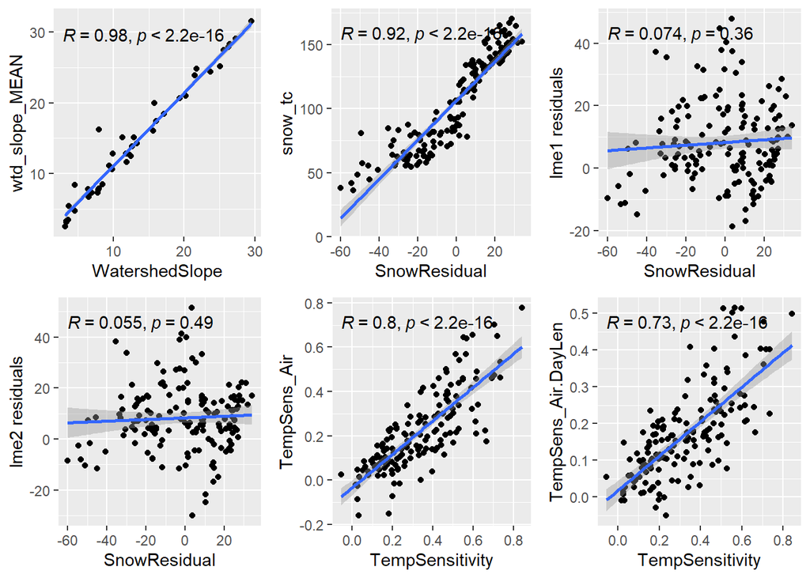

```r
p1 <- bb_dat %>%
  ggplot(aes(x = WatershedSlope, y = wtd_slope_MEAN)) +
  geom_point() +
  geom_smooth(method = "lm") +
  stat_cor()

p2 <- bb_dat %>%
  ggplot(aes(x = SnowResidual, y = snow_tc)) +
  geom_point() +
  geom_smooth(method = "lm") +
  stat_cor()

p3 <- bb_dat %>%
  ggplot(aes(x = SnowResidual, y = snow_ind)) +
  geom_point() +
  geom_smooth(method = "lm") +
  stat_cor() +
  labs(y = "lme1 residuals")

p4 <- bb_dat %>%
  ggplot(aes(x = SnowResidual, y = snow_ind_sq)) +
  geom_point() +
  geom_smooth(method = "lm") +
  stat_cor() +
  labs(y = "lme2 residuals")

p5 <- bb_dat %>%
  ggplot(aes(x = TempSensitivity, y = TempSens_Air)) +
  geom_point() +
  geom_smooth(method = "lm") +
  stat_cor()

p6 <- bb_dat %>%
  ggplot(aes(x = TempSensitivity, y = TempSens_Air.DayLen)) +
  geom_point() +
  geom_smooth(method = "lm") +
  stat_cor()

grid.arrange(p1, p2, p3, p4, p5, p6, nrow = 2)
```